# OHI: Natural Products

## 4.2 Establish parameters

```r
# identify the year to save raw data file (Need to create this file)
assessYear <- 'v2016'

# final year of data:
final.year <- 2015

# Establish: CRS, website to collect data, data selection parameters
pixel = 25000    # pixel dimension in meters for both x and y
# epsg projection 3411 - nsidc sea ice polar stereographic north (http://spatialreference.org/ref/epsg/3411/)
# epsg projection 3412 - nsidc sea ice polar stereographic south (http://spatialreference.org/ref/epsg/3412/)
prj.n = '+proj=stere +lat_0=90 +lat_ts=70 +lon_0=-45 +k=1 +x_0=0 +y_0=0 +a=6378273 +b=6356889.449 +units=m +no_defs'
prj.s = '+proj=stere +lat_0=-90 +lat_ts=-70 +lon_0=0 +k=1 +x_0=0 +y_0=0 +a=6378273 +b=6356889.449 +units=m +no_defs'
prj.mol = '+proj=moll +lon_0=0 +x_0=0 +y_0=0 +ellps=WGS84 +datum=WGS84 +units=m +no_defs'

# URL base (ub), filename format for final monthly data is nt_YYYYMM_SSS_vVV_R.bin
ub.n = 'ftp://sidads.colorado.edu/pub/DATASETS/nsidc0051_gsfc_nasateam_seaice/final-gsfc/north/monthly'
ub.s = 'ftp://sidads.colorado.edu/pub/DATASETS/nsidc0051_gsfc_nasateam_seaice/final-gsfc/south/monthly'

poles = c('n','s')
years = c(1979:final.year)  #Full range of data
months = 1:12
n.pym=length(poles)*length(years)*length(months)
i.pym = 0
t0 = Sys.time()
```

## 4.3 Function 1:

Collects the data for each month/year from the website and add to raster stack that is saved in tmp folder as: n_rasters_points.rdata or s_rasters_points.rdata. And, if it doesn’t already exist, it converts the region shapefile into a raster points file.

```r
source("ObtainingData.R")
```

## 4.4 Function 2:

Using the data from the .rdata files created in Function 1, this function calculates status and trend for shoreline ice and ice edge habitat. Data is saved in intermediate folder:

- Habitat: n_IceEdgeHabitat.csv, s_IceEdgeHabitat.csv
- Coastal Protection: n_IceShoreProtection.csv, s_IceShoreProtection.csv

```r
ref.years <- 1979:2000

source("Status_Trend.R")
```

## 4.5 Final calculations and organization

```r
n_edge <- read.csv("int/n_IceEdgeHabitat_ref1979to2000.csv")
s_edge <- read.csv("int/s_IceEdgeHabitat_ref1979to2000.csv")
edge <- rbind(n_edge, s_edge)
edge  <- edge %>%
  filter(Reference_avg1979to2000monthlypixels != 0) %>%
  filter(!(rgn_id %in% c(59, 141, 219, 4, 172, 94))) %>%  #anomolous eez regions with very little ice cover
  filter(!(rgn_id %in% c("248300", "258510", "258520", "258600", "258700"))) %>% # ccamlr: cut some regions due to minimal ice (<200 km2 per year - average of months)
  filter(rgn_nam != "DISPUTED") %>%
  mutate(habitat="seaice_edge")

n_shore <- read.csv("int/n_IceShoreProtection_ref1979to2000.csv")
s_shore <- read.csv("int/s_IceShoreProtection_ref1979to2000.csv")
shore <- rbind(n_shore, s_shore)
shore <- shore %>%
filter(Reference_avg1979to2000monthlypixels != 0) %>%
  filter(!(rgn_id %in% c(59, 89, 177, 178))) %>%  #anomolous eez regions with very little ice cover
  filter(rgn_nam != "DISPUTED") %>%
  mutate(habitat="seaice_shoreline")

data <- rbind(edge, shore)
data  <- data %>%
  mutate(km2 = Reference_avg1979to2000monthlypixels/12 * (pixel/1000)^2)

write.csv(data, "int/sea_ice.csv", row.names=FALSE)

## ice health data subset/format/save
iceHealth <- function(type ="eez", year=final.year){
  criteria1 <- ~rgn_typ == type
  dataYear <- paste("pctdevR", year, sep="_")
  filterdata <- data %>%
    filter_(criteria1)

  filterdata <- subset(filterdata, select=c(rgn_id, habitat, get(dataYear)))
  names(filterdata) <- c('rgn_id', 'habitat', 'health')
  filterdata$health <- ifelse(filterdata$health>1, 1, filterdata$health)
  write.csv(filterdata, sprintf("output/hab_ice_health_%s_%s.csv", type, year), row.names=FALSE)
}

## can also do fao and ccamlr by changing type (not sure if we will need this)
iceHealth(type="eez", year='2015') # 2016 analysis
iceHealth(type="eez", year='2014') # 2015 analysis
iceHealth(type="eez", year='2013') # 2014 analysis
iceHealth(type="eez", year='2012') # 2013 analysis
iceHealth(type="eez", year='2011') # 2013 analysis


## ice trend data subset/format/save
iceTrend <- function(type ="eez", year=final.year){
  criteria1 <- ~rgn_typ == type
  dataYear <- sprintf("Trend_%sto%s_pctdevRperyr", year-4, year)
  filterdata <- data %>%
    filter_(criteria1)

  filterdata <- subset(filterdata, select=c(rgn_id, habitat, get(dataYear)))
  names(filterdata) <- c('rgn_id', 'habitat', 'trend')
  filterdata$trend <- filterdata$trend*5
   filterdata$trend <- ifelse(filterdata$trend>1, 1, filterdata$trend)
   filterdata$trend <- ifelse(filterdata$trend<(-1), -1, filterdata$trend)
  write.csv(filterdata, sprintf("output/hab_ice_trend_%s_%s.csv", type, year), row.names=FALSE)
}

## can also do fao and ccamlr by changing type (not sure if we will need this)
iceTrend(type="eez", year=2015) # 2016 analysis
iceTrend(type="eez", year=2014) # 2015 analysis
iceTrend(type="eez", year=2013) # 2014 analysis
iceTrend(type="eez", year=2012) # 2013 analysis
iceTrend(type="eez", year=2011) # 2013 analysis

## ice extent data subset/format/save
iceExtent <- function(type ="eez"){
  criteria1 <- ~rgn_typ == type

  filterdata <- data %>%
    filter_(criteria1)

  filterdata <- subset(filterdata, select=c(rgn_id, habitat, km2))
  write.csv(filterdata, sprintf("output/hab_ice_extent_%s.csv", type), row.names=FALSE)
}

## can also do fao and ccamlr by changing type (not sure if we will need this)
iceExtent(type="eez") # all years
```

## 4.6 Checking the data

1. Compare to last year’s data: There may be small changes to health, but in general, there should be a strong correlation between these data. This is what we observed in the data. However, we have changed our method of calculating trend (proportional change vs. absolute change), so there might be significant differences in these values.
2. Pair with region names for sanity check.

```r
## Health
old <- read.csv('../v2015/data/hab_ice_health_eez_2014.csv') %>%
  select(rgn_id, habitat, old_health=health)

new <- read.csv('output/hab_ice_health_eez_2014.csv') %>%
  left_join(old)
```

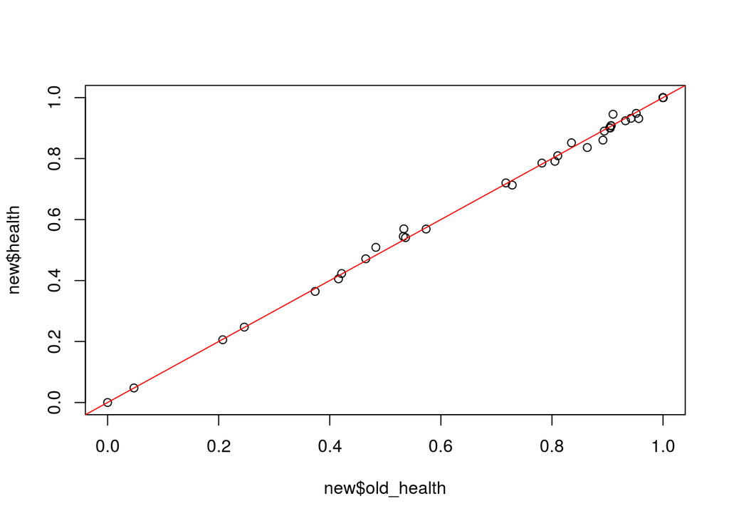

```r
plot(new$old_health, new$health)
abline(0,1, col="red")
```

```r
## Trend
old <- read.csv('../v2015/data/hab_ice_trend_eez_2014.csv') %>%
  select(rgn_id, habitat, old_trend=trend)

new <- read.csv('output/hab_ice_trend_eez_2014.csv') %>%
  left_join(old)
```

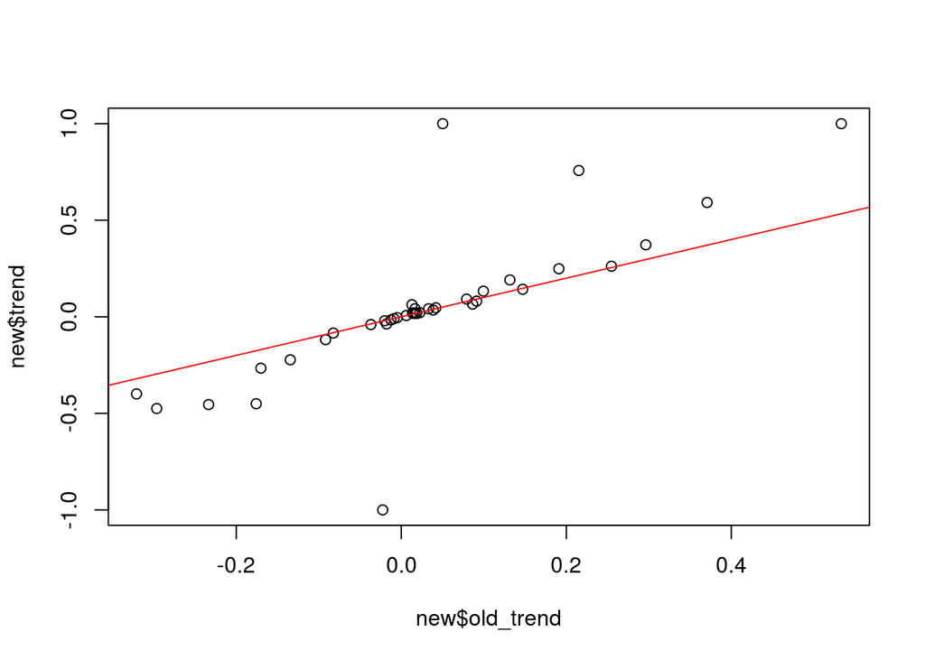

```r
plot(new$old_trend, new$trend)
abline(0,1, col="red")
```

```r
## Pair with region names
library(ohicore)

regions <- rgn_master %>%
  select(rgn_id = rgn_id_2013, rgn_name = rgn_nam_2013) %>%
  unique()

data <- read.csv('output/hab_ice_health_eez_2015.csv') %>%
  left_join(regions, by="rgn_id") %>%
  arrange(habitat, health)
```